# 603-Walmart Sales

2024-03-19

#### 1. Project Objectives

This project directs toward multiple linear regression analysis to explore the numerous factors influencing Walmart’s weekly sales, including macroeconomic indicators, weather conditions, fuel prices, and holiday impacts

The following variables shown below were measured and are considered for this problem

1. Weekly_sales ($) sales for the given department in the given store.
2. Temperature (F) - average temperature in the region.
3. Fuel_Price - cost of fuel in the region.
4. CPI - the consumer price index
5. Unemployment - the unemployment rate.
6. IsHoliday - whether the week is a special holiday week.
7. Size - floor area in SQF

Here is the full addtitive model that is the starting point to optimize to the best predictive model.

$$\hat{\text{Weekly_Sales}_i} = \beta_{0} + \beta_{1}\text{Temperature}_i
+ \beta_{2}\text{Fuel_price}_i + \beta_{3}\text{CPI}_i +
\beta_{4}\text{Unemployment}_i + \beta_{5}\text{Size}_i +
\beta_{6}\text{Holiday}_i$$

#### 2. Results

##### 2.1 Find the best predictive model

##### 2.1.1 Use the individual T-test to evaluate the significant predictors from the full model at $\alpha=0.05$ and write the estimated best fit model.

- Install packages

```r
#install.packages("GGally")
```

- Read the dataset

```r
walmart = read.csv("C:/Users/Admin/My Drive/MDSA/Dataset/01. Supply Chain/Walmart/Walmart_sales_merged.csv")
walmartNEW = walmart
walmartNEW[which(walmart$Holiday_Flag=="1"),4] = "Yes"
walmartNEW[which(walmart$Holiday_Flag=="0"),4] = "No"
head(walmartNEW ,3)
```

|  | Store | Date | Weekly_Sales | Holiday_Flag | Temperature | Fuel_Price | CPI | Unemployment | Type | Size |
| --- | --- | --- | --- | --- | --- | --- | --- | --- | --- | --- |
| 1 | 1 | 5/2/2010 | 1643691 | No | 42.31 | 2.572 | 211.0964 | 8.106 | A | 151315 |
| 2 | 1 | 12/2/2010 | 1641957 | Yes | 38.51 | 2.548 | 211.2422 | 8.106 | A | 151315 |
| 3 | 1 | 19-02-2010 | 1611968 | No | 39.93 | 2.514 | 211.2891 | 8.106 | A | 151315 |

```r
full = lm(Weekly_Sales~Temperature+Fuel_Price+CPI+Unemployment+Size+Holiday_Flag,data=walmartNEW)
summary(full)
```

```
Call:
lm(formula = Weekly_Sales ~ Temperature + Fuel_Price + CPI +
    Unemployment + Size + Holiday_Flag, data = walmartNEW)

Residuals:
    Min      1Q  Median      3Q     Max
-632618 -247327  -22213  158506 2696850

Coefficients:
                  Estimate Std. Error t value Pr(>|t|)
(Intercept)      5.032e+05  4.787e+04  10.511  < 2e-16 ***
Temperature      1.362e+03  2.347e+02   5.802 6.85e-09 ***
Fuel_Price      -2.442e+04  9.209e+03  -2.652  0.00803 **
CPI             -1.388e+03  1.140e+02 -12.175  < 2e-16 ***
Unemployment    -2.077e+04  2.328e+03  -8.923  < 2e-16 ***
Size             7.222e+00  6.482e-02 111.411  < 2e-16 ***
Holiday_FlagYes  9.467e+04  1.615e+04   5.863 4.76e-09 ***
---
Signif. codes:  0 ‘***’ 0.001 ‘**’ 0.01 ‘*’ 0.05 ‘.’ 0.1 ‘ ’ 1

Residual standard error: 325600 on 6428 degrees of freedom
Multiple R-squared:  0.6675,    Adjusted R-squared:  0.6672
F-statistic:  2151 on 6 and 6428 DF,  p-value: < 2.2e-16
```

$$\hat{\text{Weekly_Sales}_i} = 503200 + 1362\text{Temperature}_i -
24420\text{Fuel_price}_i - 1388\text{CPI}_i -
20770\text{Unemployment}_i + 7.222\text{Size}_i + 94670\text{Holiday}_i$$

##### 2.1.2 Use all-possible-regressions-selection to find the ‘’best’’ predictors of Week;y_sales. Pick model based on AIC? Adjusted $R^2$?

- Stepwise regression

```r
library(olsrr)
stepmod_sales = ols_step_both_p(full,p_ent=0.1,p_remove=0.3,details=FALSE)
summary(stepmod_sales$model)
```

```
Call:
lm(formula = paste(response, "~", paste(preds, collapse = " + ")),
    data = l)

Residuals:
    Min      1Q  Median      3Q     Max
-632618 -247327  -22213  158506 2696850

Coefficients:
                  Estimate Std. Error t value Pr(>|t|)
(Intercept)      5.032e+05  4.787e+04  10.511  < 2e-16 ***
Size             7.222e+00  6.482e-02 111.411  < 2e-16 ***
CPI             -1.388e+03  1.140e+02 -12.175  < 2e-16 ***
Unemployment    -2.077e+04  2.328e+03  -8.923  < 2e-16 ***
Holiday_FlagYes  9.467e+04  1.615e+04   5.863 4.76e-09 ***
Temperature      1.362e+03  2.347e+02   5.802 6.85e-09 ***
Fuel_Price      -2.442e+04  9.209e+03  -2.652  0.00803 **
---
Signif. codes:  0 ‘***’ 0.001 ‘**’ 0.01 ‘*’ 0.05 ‘.’ 0.1 ‘ ’ 1

Residual standard error: 325600 on 6428 degrees of freedom
Multiple R-squared:  0.6675,    Adjusted R-squared:  0.6672
F-statistic:  2151 on 6 and 6428 DF,  p-value: < 2.2e-16
```

- Forward Regression

```r
library(olsrr)
for_sales = ols_step_forward_p(full,p_val=0.1,details=FALSE)
summary(for_sales$model)
```

```
Call:
lm(formula = paste(response, "~", paste(preds, collapse = " + ")),
    data = l)

Residuals:
    Min      1Q  Median      3Q     Max
-632618 -247327  -22213  158506 2696850

Coefficients:
                  Estimate Std. Error t value Pr(>|t|)
(Intercept)      5.032e+05  4.787e+04  10.511  < 2e-16 ***
Size             7.222e+00  6.482e-02 111.411  < 2e-16 ***
CPI             -1.388e+03  1.140e+02 -12.175  < 2e-16 ***
Unemployment    -2.077e+04  2.328e+03  -8.923  < 2e-16 ***
Holiday_FlagYes  9.467e+04  1.615e+04   5.863 4.76e-09 ***
Temperature      1.362e+03  2.347e+02   5.802 6.85e-09 ***
Fuel_Price      -2.442e+04  9.209e+03  -2.652  0.00803 **
---
Signif. codes:  0 ‘***’ 0.001 ‘**’ 0.01 ‘*’ 0.05 ‘.’ 0.1 ‘ ’ 1

Residual standard error: 325600 on 6428 degrees of freedom
Multiple R-squared:  0.6675,    Adjusted R-squared:  0.6672
F-statistic:  2151 on 6 and 6428 DF,  p-value: < 2.2e-16
```

- Backward Regression

```r
library(olsrr)
back_sales = ols_step_backward_p(full,p_val=0.1,details=FALSE)
summary(back_sales$model)
```

```
Call:
lm(formula = paste(response, "~", paste(c(include, cterms), collapse = " + ")),
    data = l)

Residuals:
    Min      1Q  Median      3Q     Max
-632618 -247327  -22213  158506 2696850

Coefficients:
                  Estimate Std. Error t value Pr(>|t|)
(Intercept)      5.032e+05  4.787e+04  10.511  < 2e-16 ***
Temperature      1.362e+03  2.347e+02   5.802 6.85e-09 ***
Fuel_Price      -2.442e+04  9.209e+03  -2.652  0.00803 **
CPI             -1.388e+03  1.140e+02 -12.175  < 2e-16 ***
Unemployment    -2.077e+04  2.328e+03  -8.923  < 2e-16 ***
Size             7.222e+00  6.482e-02 111.411  < 2e-16 ***
Holiday_FlagYes  9.467e+04  1.615e+04   5.863 4.76e-09 ***
---
Signif. codes:  0 ‘***’ 0.001 ‘**’ 0.01 ‘*’ 0.05 ‘.’ 0.1 ‘ ’ 1

Residual standard error: 325600 on 6428 degrees of freedom
Multiple R-squared:  0.6675,    Adjusted R-squared:  0.6672
F-statistic:  2151 on 6 and 6428 DF,  p-value: < 2.2e-16
```

##### 2.1.3 Improve this model by adding an interaction term(s). Evaluate whether the interaction term(s) is(are) significant to be added in the model at $\alpha = 0.05$. Summarize which model would you suggest using for predicting y.

```r
interact01 = lm(Weekly_Sales~(Temperature+Fuel_Price+CPI+Unemployment+Size+Holiday_Flag)^2,data=walmartNEW)
summary(interact01)
```

```
Call:
lm(formula = Weekly_Sales ~ (Temperature + Fuel_Price + CPI +
    Unemployment + Size + Holiday_Flag)^2, data = walmartNEW)

Residuals:
    Min      1Q  Median      3Q     Max
-747965 -229761  -17333  144286 2720603

Coefficients:
                               Estimate Std. Error t value Pr(>|t|)
(Intercept)                   1.497e+06  3.057e+05   4.897 9.99e-07 ***
Temperature                   4.184e+03  2.732e+03   1.531  0.12572
Fuel_Price                   -2.321e+05  7.676e+04  -3.023  0.00251 **
CPI                          -1.183e+04  1.186e+03  -9.980  < 2e-16 ***
Unemployment                 -1.131e+05  2.408e+04  -4.697 2.69e-06 ***
Size                          1.211e+01  7.331e-01  16.522  < 2e-16 ***
Holiday_FlagYes               6.957e+04  1.952e+05   0.356  0.72161
Temperature:Fuel_Price        1.569e+03  5.574e+02   2.815  0.00489 **
Temperature:CPI              -3.453e+01  6.279e+00  -5.499 3.98e-08 ***
Temperature:Unemployment     -1.546e+02  1.229e+02  -1.258  0.20842
Temperature:Size             -4.584e-03  3.669e-03  -1.249  0.21162
Temperature:Holiday_FlagYes   8.268e+02  8.517e+02   0.971  0.33171
Fuel_Price:CPI                1.286e+03  2.559e+02   5.027 5.13e-07 ***
Fuel_Price:Unemployment      -9.721e+03  5.479e+03  -1.774  0.07607 .
Fuel_Price:Size              -9.085e-02  1.437e-01  -0.632  0.52713
Fuel_Price:Holiday_FlagYes    7.132e+03  4.123e+04   0.173  0.86266
CPI:Unemployment              1.251e+03  7.608e+01  16.443  < 2e-16 ***
CPI:Size                     -8.140e-03  1.746e-03  -4.663 3.17e-06 ***
CPI:Holiday_FlagYes          -6.435e+02  4.456e+02  -1.444  0.14877
Unemployment:Size            -3.530e-01  3.600e-02  -9.808  < 2e-16 ***
Unemployment:Holiday_FlagYes -1.044e+03  8.926e+03  -0.117  0.90690
Size:Holiday_FlagYes          6.019e-01  2.489e-01   2.418  0.01562 *
---
Signif. codes:  0 ‘***’ 0.001 ‘**’ 0.01 ‘*’ 0.05 ‘.’ 0.1 ‘ ’ 1

Residual standard error: 313800 on 6413 degrees of freedom
Multiple R-squared:  0.6918,    Adjusted R-squared:  0.6908
F-statistic: 685.4 on 21 and 6413 DF,  p-value: < 2.2e-16
```

```r
interact02 = lm(Weekly_Sales~Temperature+Fuel_Price+CPI+Unemployment+Size+Holiday_Flag+
                          Temperature*Fuel_Price+ Temperature*CPI +
                          Fuel_Price*CPI+
                          CPI*Unemployment+CPI*Size+
                          Unemployment*Size + Size*Holiday_Flag,data=walmartNEW)
summary(interact02)
```

```
Call:
lm(formula = Weekly_Sales ~ Temperature + Fuel_Price + CPI +
    Unemployment + Size + Holiday_Flag + Temperature * Fuel_Price +
    Temperature * CPI + Fuel_Price * CPI + CPI * Unemployment +
    CPI * Size + Unemployment * Size + Size * Holiday_Flag, data = walmartNEW)

Residuals:
    Min      1Q  Median      3Q     Max
-750780 -227632  -19259  144025 2720342

Coefficients:
                         Estimate Std. Error t value Pr(>|t|)
(Intercept)             2.020e+06  2.152e+05   9.386  < 2e-16 ***
Temperature             2.581e+03  2.219e+03   1.163  0.24481
Fuel_Price             -3.401e+05  4.961e+04  -6.855 7.78e-12 ***
CPI                    -1.266e+04  1.127e+03 -11.232  < 2e-16 ***
Unemployment           -1.580e+05  1.239e+04 -12.755  < 2e-16 ***
Size                    1.154e+01  4.803e-01  24.022  < 2e-16 ***
Holiday_FlagYes         1.222e+04  3.531e+04   0.346  0.72923
Temperature:Fuel_Price  1.419e+03  5.404e+02   2.626  0.00865 **
Temperature:CPI        -3.233e+01  5.996e+00  -5.392 7.23e-08 ***
Fuel_Price:CPI          1.447e+03  2.406e+02   6.015 1.90e-09 ***
CPI:Unemployment        1.265e+03  7.561e+01  16.731  < 2e-16 ***
CPI:Size               -8.156e-03  1.669e-03  -4.887 1.05e-06 ***
Unemployment:Size      -3.557e-01  3.554e-02 -10.009  < 2e-16 ***
Size:Holiday_FlagYes    6.417e-01  2.432e-01   2.639  0.00833 **
---
Signif. codes:  0 ‘***’ 0.001 ‘**’ 0.01 ‘*’ 0.05 ‘.’ 0.1 ‘ ’ 1

Residual standard error: 313900 on 6421 degrees of freedom
Multiple R-squared:  0.6912,    Adjusted R-squared:  0.6906
F-statistic:  1106 on 13 and 6421 DF,  p-value: < 2.2e-16
```

- Check Anova tables The hypothesis: $H_{0}:\beta_{i}= 0; H_{\alpha}:\beta_{i} \neq 0$

```r
anova(interact02,interact01)
```

```
Analysis of Variance Table

Model 1: Weekly_Sales ~ Temperature + Fuel_Price + CPI + Unemployment +
    Size + Holiday_Flag + Temperature * Fuel_Price + Temperature *
    CPI + Fuel_Price * CPI + CPI * Unemployment + CPI * Size +
    Unemployment * Size + Size * Holiday_Flag
Model 2: Weekly_Sales ~ (Temperature + Fuel_Price + CPI + Unemployment +
    Size + Holiday_Flag)^2
  Res.Df        RSS Df  Sum of Sq      F Pr(>F)
1   6421 6.3274e+14
2   6413 6.3163e+14  8 1.1099e+12 1.4086 0.1872
```

- p value > 0.05, we fail to reject Null Hypothesis, accept the reduced model interact02

##### 2.1.4 Improve this model by high order terms

- Make a pairs plot to look if we should do anything higher order

The hypothesis: $H_{0}:\beta_{i}= 0; H_{\alpha}:\beta_{i} \neq 0 \text{ where i is at the variables with high orders}$

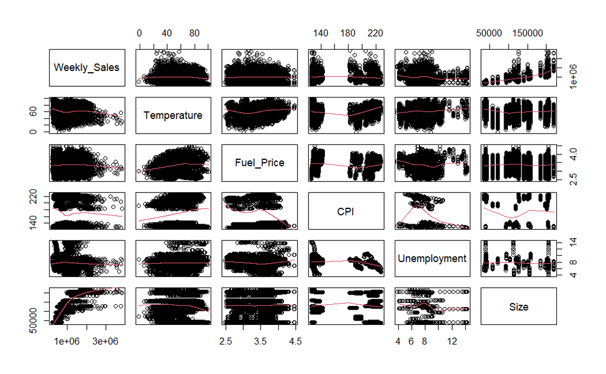

```r
library(GGally)
saleswm_df = data.frame(walmartNEW$Temperature,walmartNEW$Fuel_Price,walmartNEW$CPI,walmartNEW$Unemployment,walmartNEW$Size,walmartNEW$Holiday_Flag)
pairs(~Weekly_Sales + Temperature + Fuel_Price + CPI + Unemployment + Size,data=walmartNEW,panel=panel.smooth)
```

- It looks like Size & Fuel_Price could be higher order

```r
highorder1 = lm(Weekly_Sales~Temperature+Fuel_Price+I(Fuel_Price^2)+I(Fuel_Price^3)+
                CPI+Unemployment+Size+I(Size^2)+I(Size^3)+factor(Holiday_Flag),
                data=walmartNEW)
summary(highorder1)
```

```
Call:
lm(formula = Weekly_Sales ~ Temperature + Fuel_Price + I(Fuel_Price^2) +
    I(Fuel_Price^3) + CPI + Unemployment + Size + I(Size^2) +
    I(Size^3) + factor(Holiday_Flag), data = walmartNEW)

Residuals:
    Min      1Q  Median      3Q     Max
-646663 -220661  -44244  138984 2727256

Coefficients:
                          Estimate Std. Error t value Pr(>|t|)
(Intercept)             -9.826e+06  1.712e+06  -5.740 9.92e-09 ***
Temperature              1.754e+03  2.399e+02   7.312 2.95e-13 ***
Fuel_Price               8.596e+06  1.534e+06   5.603 2.20e-08 ***
I(Fuel_Price^2)         -2.455e+06  4.556e+05  -5.388 7.37e-08 ***
I(Fuel_Price^3)          2.298e+05  4.469e+04   5.142 2.80e-07 ***
CPI                     -1.254e+03  1.176e+02 -10.664  < 2e-16 ***
Unemployment            -2.479e+04  2.297e+03 -10.793  < 2e-16 ***
Size                     2.349e+01  1.739e+00  13.506  < 2e-16 ***
I(Size^2)               -1.717e-04  1.592e-05 -10.787  < 2e-16 ***
I(Size^3)                5.008e-10  4.241e-11  11.810  < 2e-16 ***
factor(Holiday_Flag)Yes  9.449e+04  1.575e+04   5.998 2.11e-09 ***
---
Signif. codes:  0 ‘***’ 0.001 ‘**’ 0.01 ‘*’ 0.05 ‘.’ 0.1 ‘ ’ 1

Residual standard error: 317300 on 6424 degrees of freedom
Multiple R-squared:  0.6844,    Adjusted R-squared:  0.6839
F-statistic:  1393 on 10 and 6424 DF,  p-value: < 2.2e-16
```

```r
highorder2 = lm(Weekly_Sales~Temperature+Fuel_Price+I(Fuel_Price^2)+I(Fuel_Price^3)+I(Fuel_Price^4)+CPI+Unemployment+Size+I(Size^2)+I(Size^3)+I(Size^4)+factor(Holiday_Flag),data=walmartNEW)
summary(highorder2)
```

```
Call:
lm(formula = Weekly_Sales ~ Temperature + Fuel_Price + I(Fuel_Price^2) +
    I(Fuel_Price^3) + I(Fuel_Price^4) + CPI + Unemployment +
    Size + I(Size^2) + I(Size^3) + I(Size^4) + factor(Holiday_Flag),
    data = walmartNEW)

Residuals:
    Min      1Q  Median      3Q     Max
-637215 -218484  -44124  136688 2716243

Coefficients:
                          Estimate Std. Error t value Pr(>|t|)
(Intercept)              8.502e+06  1.131e+07   0.752   0.4522
Temperature              1.676e+03  2.444e+02   6.856 7.73e-12 ***
Fuel_Price              -1.314e+07  1.353e+07  -0.971   0.3316
I(Fuel_Price^2)          7.227e+06  6.021e+06   1.200   0.2301
I(Fuel_Price^3)         -1.670e+06  1.182e+06  -1.413   0.1577
I(Fuel_Price^4)          1.385e+05  8.628e+04   1.605   0.1085
CPI                     -1.233e+03  1.222e+02 -10.088  < 2e-16 ***
Unemployment            -2.411e+04  2.319e+03 -10.397  < 2e-16 ***
Size                     1.367e+01  5.640e+00   2.424   0.0154 *
I(Size^2)               -2.922e-05  7.888e-05  -0.370   0.7111
I(Size^3)               -3.206e-10  4.445e-10  -0.721   0.4708
I(Size^4)                1.634e-15  8.761e-16   1.865   0.0623 .
factor(Holiday_Flag)Yes  9.206e+04  1.579e+04   5.832 5.75e-09 ***
---
Signif. codes:  0 ‘***’ 0.001 ‘**’ 0.01 ‘*’ 0.05 ‘.’ 0.1 ‘ ’ 1

Residual standard error: 317200 on 6422 degrees of freedom
Multiple R-squared:  0.6847,    Adjusted R-squared:  0.6841
F-statistic:  1162 on 12 and 6422 DF,  p-value: < 2.2e-16
```